# NRC290B - Intro to Quantitative Ecology

Random Numbers In-Class Group Activity

# 1 Introduction

One of the best ways to improve your R skills and comfort level is to experiment with lots of variations on code you already know.

One of the best ways to learn about probability distributions and their relationship to real data is to experiment with random number generation.

# 2 Random Numbers in R

Because R is a programming language specialized for statistical analysis, it has some sophisticated random number generators built in.

Note: The proper term for random numbers generated via computer is **pseudorandom**.

We hope our CPU always produces the same results when we give them the same instructions. Current computers cannot produce truly *random* numbers (but quantum computers may be able to one day).

We do have very good algorithms for producing sequences of numbers that have the statistical properties of sequences of truly random numbers.

One desirable property of *pseudorandom numbers* is that we can choose what number we want R to use as a starting key, called the **random seed** to the generator.

When we specify a seed, R will always create the same sequence. This is useful when we want to test different code on the same data.

## 2.1 Random Number Functions

R’s random number functions are all based on **probability distributions**.

Some of the most famous distributions are the Normal, Uniform, Binomial, and Poisson distributions. The corresponding R random number generating functions are:

- `rnorm()`
- `runif()`
- `rbinom()`
- `rpois()`

Here is a demo using the Normal distribution:

```r
# generate a sequence of 20 normally distributed numbers:
rnorm(n = 20)
```

```
##  [1]  0.82379803 -0.55812000 -0.72780334  0.71290391  0.96129041  0.40266164
##  [7] -0.78163033 -0.06331474 -0.42151106 -0.79880967 -0.31543876 -0.41045572
## [13]  0.20837122  0.25103168 -1.27089330  2.21435476 -0.95109009 -0.15241728
## [19] -1.31098439 -1.27962436
```

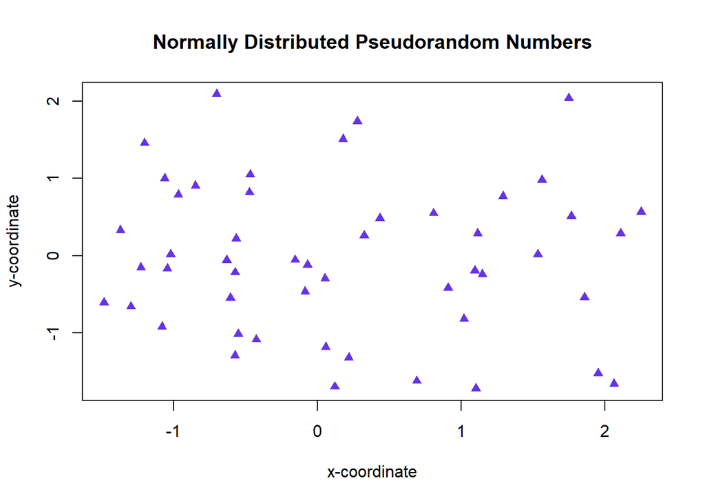

```r
# generate two sequences that you can use as coordinates to make a plot
n_pts = 50
x = rnorm(n_pts)
y = rnorm(n_pts)
plot(
  x, y,
  xlab = "x-coordinate", ylab = "y-coordinate",
  main = "Normally Distributed Pseudorandom Numbers",
  pch = 17, col = rgb(0.4, 0.2, 0.9, 1))
```

We can also plot a histogram:

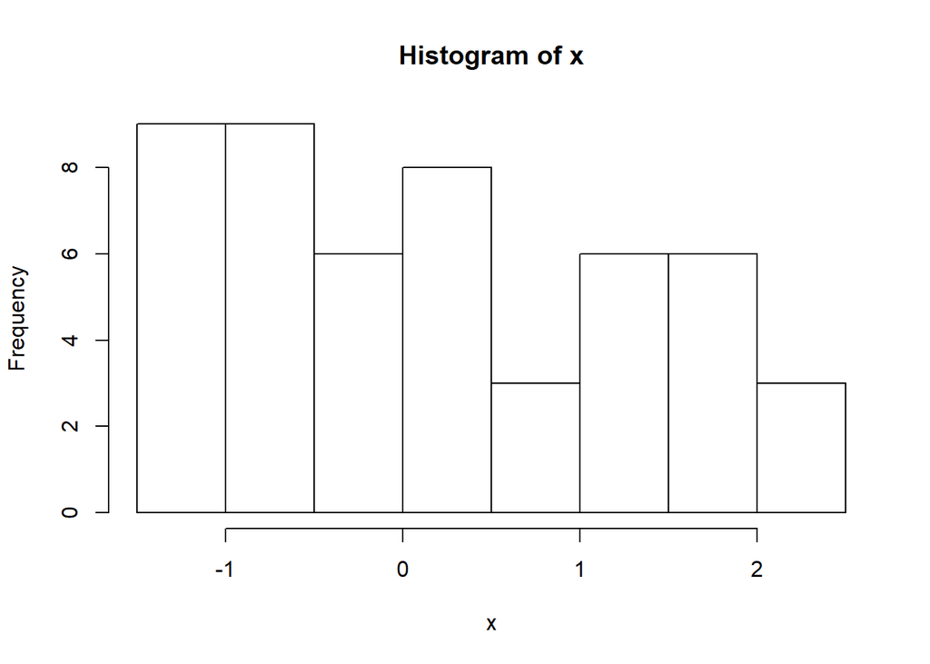

```r
hist(x)
```

# 3 Exercises

## 3.1 Uniform random numbers

Experiment with the `runif` function. Check out the help entry. Try to create sequences of different lengths: 5, 50, 500.

What are the default upper and lower bounds of the random numbers? How can you change these?

Create the following data and plots:

### 3.1.1 Histograms

Plot histograms with the following uniform random number sequences:

**Question 1**: Before you create any plots, discuss your predictions about how the histograms should appear.

- **Unif hist 1**: 5 numbers between 0 and 1.
- **Unif hist 2**: 20 numbers between 10 and 100.
- **Unif hist 3**: 200 numbers between -10 and 10.
- **Unif hist 4**: 5000 numbers between 5 and 37.
- **Question 2**: What are the quantitative and qualitative differences you see in your histograms?
- **Question 3**: Did the shapes of the histograms conform to your expectations?

### 3.1.2 Scatterplots

Generate scatterplots with with x- and y-coordinates using the following parameters:

- **Question 4**: Before you create the plots, try to predict the qualitative appearance of the scatterplots.
- **Unif scatter 1**: 15 numbers: x coordinates between 0 and 1, y coordinates between 0 and 20.
- **Unif scatter 2**: 5000 numbers: x-coordinates and y-coordinates between 10 and 100.

Compare the plots to your expectations.

## 3.2 Normal Distribution

You will use the `rnorm()` function for these exercises. Check the help entry and the internets to learn how to specify the mean and standard deviations.

### 3.2.1 Histograms

Plot histograms using normally-distributed numbers with the following parameters:

- **Norm hist 1**: 5 numbers (any values you want for standard deviation and mean)
- **Norm hist 2**: 12 numbers (any values you want for standard deviation and mean)
- **Norm hist 3**: 500 numbers with standard deviation of 3 and mean of 15
- **Norm hist 4**: 500 numbers with standard deviation of 0.5 and mean of 15

For **Norm hist 3** and **Norm hist 4**, use the `xlim` argument to plot both using the same range of x values for both plots.

I suggest you try an x range from 5 to 25 as a starting point.

- **Question 5**: Assume that you didn’t know the numbers were Normally-distributed. Describe your thought process if you had to make a guess about what distribution would best fit the data.
- **Question 6**: Qualitatively describe the differences you see between **Norm hist 3** and **Norm hist 4**

### 3.2.2 Extra Credit

- **Norm scatter 1**: Create a scatterplot with **5000** normally-distributed x and y coordinates.
- **Extra credit question**: Use your knowledge about the uniform and Normal distributions to explain the differences in patterns between **Norm scatter 1** and **Unif scatter 2**.

# 4 Report

Submit a report with short answers (1 to 3 sentences) to questions 1 - 6.  
Include plots of **Unif hist 3** and **Unif hist 4**. Include plots of **Norm hist 3** and **Norm hist 4**.

The questions are worth 8 points each. The plots are worth 5 points each. The extra credit is worth a total of 7 points.

If you complete the extra credit section, include both a short answer to the question and a plot of **Norm scatter 1**